# Race to Fish

Ernesto Carrella

January 13, 2016

## Race to fish

Start with open-access fisheries. Absent any preference for leisure or tradeoff between profitability and safety, fishers should go out every day that it profitable to do so.  
Assuming the price for fish decreases as more fishers are active we ought to reach an equilibrium such that a steady number of fishers go out every month each making approximately no profits.

If we impose a TAC policy (with no property rights) we should see more or less the same number of fishers go out every month until the quota is consumed at which point no boats should be at sea.  
If we impose a full ITQ instead we should see fishers redistribute themselves uniformly throughout the year so as to maximize their own profits.

It turns out that this result is achievable by our model without the need to introduce complicated long-term planning (even though we should at some point) or new preferences.

There are 100 homogeneous fishers in the model. Each of them has random preferences over which month they prefer to go out. Every year, much like all the other decisions in the model, the agents have small chance of randomly pick new months they want to go out or copy a friend who is doing better, if they know any.  
The market is rigged in such a way that if there are more than 50 fishers at sea at any month then profits are negative and when there are less than 45 profits are very positive. Biomass is fixed and unchanging.

It turns out that with open-access, again by exploration-imitation, you end up with a stable (after averaging out over many runs at least) number of fishers at each month, more or less around the 0 profit value.  
When TAC is implemented there is a slight increase in the number of fishers in the first month although this is mostly an artifact due to the price being very high on the very first days of the simulation (since for many months no fish were sold) but in general the agents fish at more or less the same intensity as the open-access scenario for as long as quotas last.  
The ITQ scenario instead has fishers quite smartly spreading out maximizing profits until quotas last. It is, without accounting for noise, exactly how you’d run a monopoly which is I think what we’d expect the results to look like.

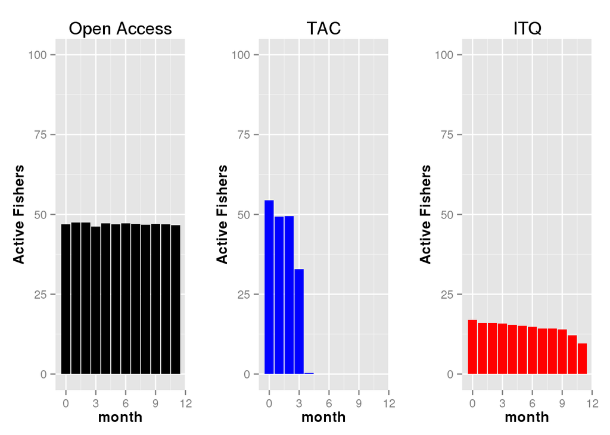

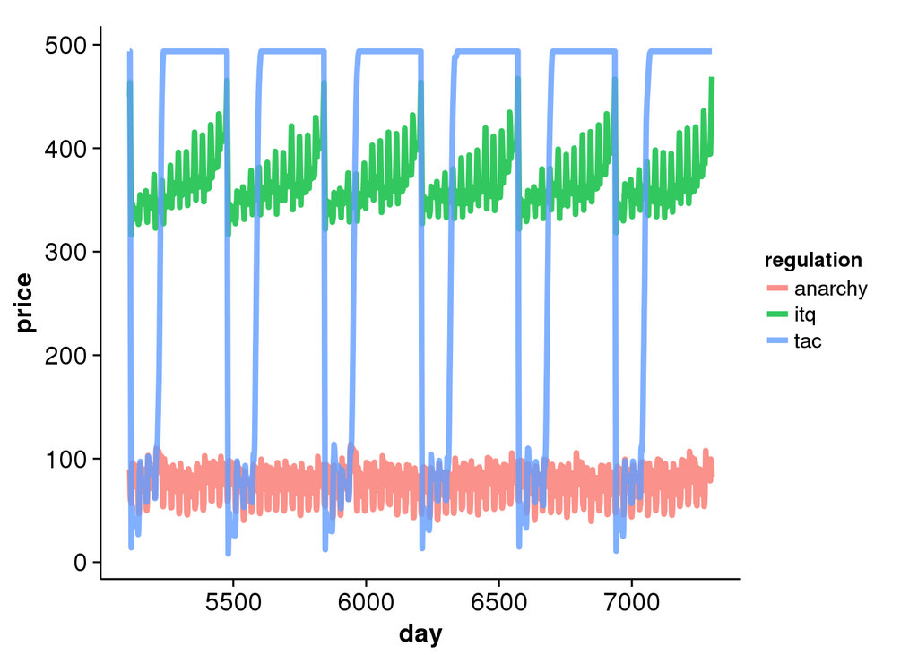

Average Last Year Profits per Fisher

| Regulation | Average Profits |
| --- | --- |
| Open Access | -21468.570 |
| ITQ | 1399158.299 |
| TAC | -5102.499 |

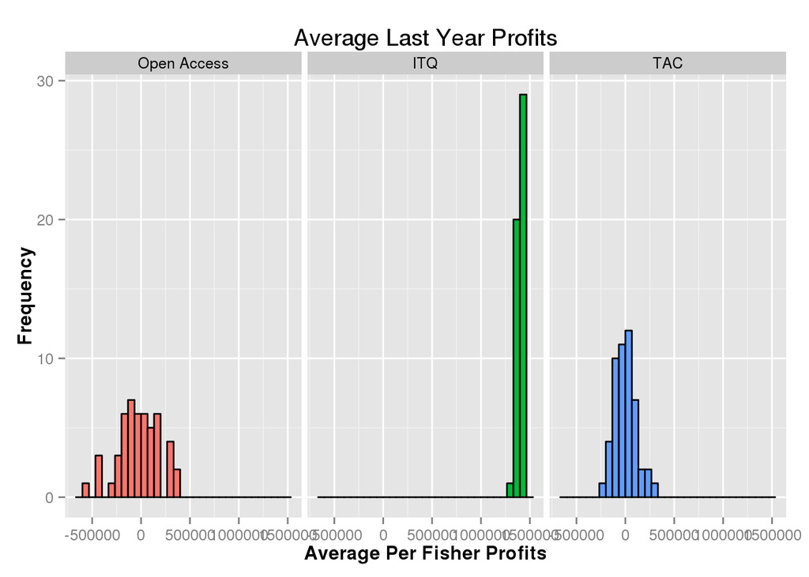

## A special case of TACs increasing race to fish

As mentioned above, I do not expect TAC alone to further incentivize race to fish compared to the no-regulations scenario. This is because, in absence of additional constraints like satisficing behaviour or leisure incentives, fishers will not use their boat if it is improfitable to do so.

However there are some corner cases where TAC indeed shows more racing to fish compared to the no-regulations scenario. This happens when the price of fish responds to an increase in supply only after a long delay. When TAC is in place there is usually no fishing in the late months of a year (as quotas will have finished by then). This means that at the beginning of the new year fish price must be high. If it takes some days before new fishing impacts prices it might be profitable for almost everyone to go out fishing on the very first month of the year. This is a much larger turnout than in the no-rules scenario.

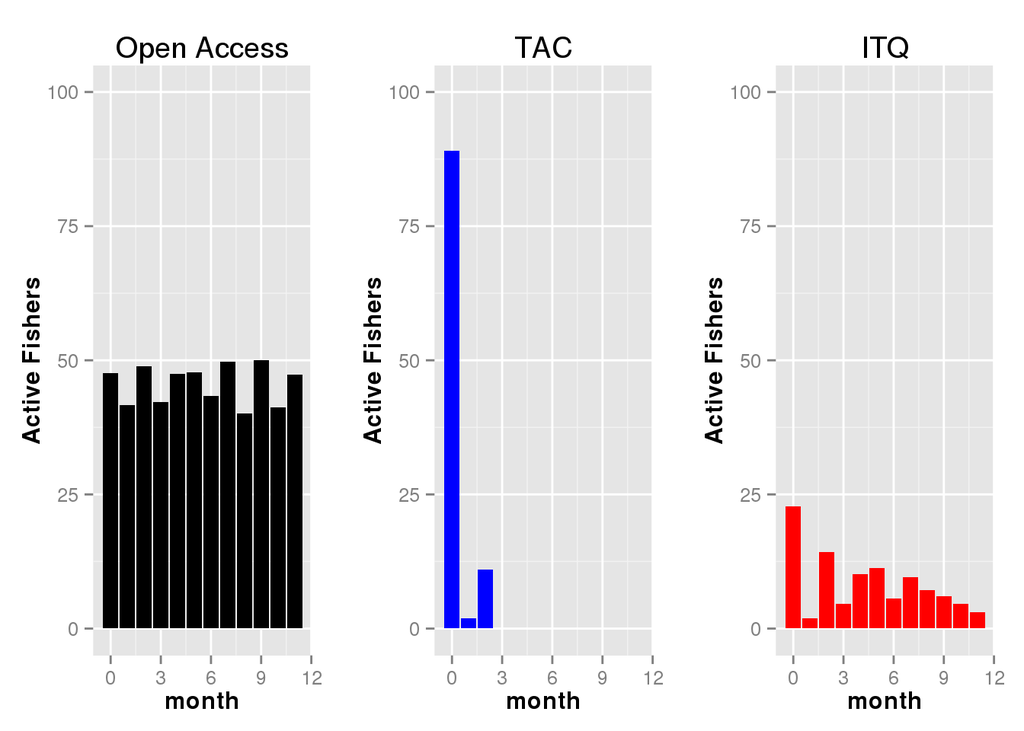

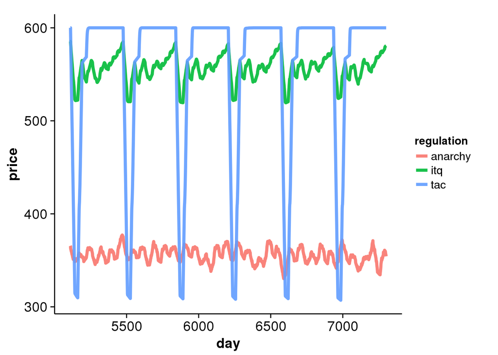

The TAC case instead has two spikes at the first and third month of the year, coinciding with prices being artificially high.

Interestingly both TAC and ITQ policies generate positive profits on average even though ITQs still generate substantially more

Average Last Year Profits per Fisher

| Regulation | Profits |
| --- | --- |
| Open Access | 4060.142 |
| ITQ | 561804.154 |
| TAC | 246365.687 |

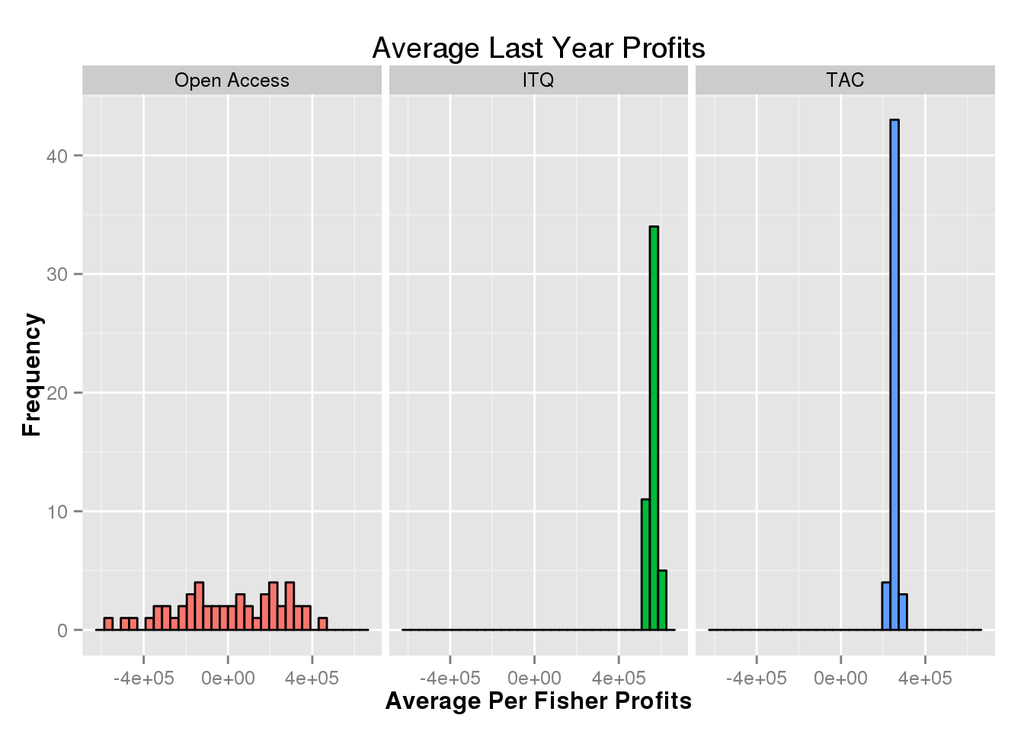